# **EasyVisa Project**

Context: Business communities in the United States are facing high demand for human resources, but one of the constant challenges is identifying and attracting the right talent, which is perhaps the most important element in remaining competitive. Companies in the United States look for hard-working, talented, and qualified individuals both locally as well as abroad.

The Immigration and Nationality Act (INA) of the US permits foreign workers to come to the United States to work on either a temporary or permanent basis. The act also protects US workers against adverse impacts on their wages or working conditions by ensuring US employers' compliance with statutory requirements when they hire foreign workers to fill workforce shortages. The immigration programs are administered by the Office of Foreign Labor Certification (OFLC).

OFLC processes job certification applications for employers seeking to bring foreign workers into the United States and grants certifications in those cases where employers can demonstrate that there are not sufficient US workers available to perform the work at wages that meet or exceed the wage paid for the occupation in the area of intended employment.

## **Objective:**

In FY 2016, the OFLC processed 775,979 employer applications for 1,699,957 positions for temporary and permanent labor certifications. This was a nine percent increase in the overall number of processed applications from the previous year. The process of reviewing every case is becoming a tedious task as the number of applicants is increasing every year.

The increasing number of applicants every year calls for a Machine Learning based solution that can help in shortlisting the candidates having higher chances of VISA approval. OFLC has hired your firm EasyVisa for data-driven solutions. You as a data scientist have to analyze the data provided and, with the help of a classification model:

Facilitate the process of visa approvals. Recommend a suitable profile for the applicants for whom the visa should be certified or denied based on the drivers that significantly influence the case status.

Data Description The data contains the different attributes of the employee and the employer. The detailed data dictionary is given below.

case_id: ID of each visa application

continent: Information of continent the employee

education_of_employee: Information of education of the employee

has_job_experience: Does the employee has any job experience? Y= Yes; N = No

requires_job_training: Does the employee require any job training? Y = Yes; N = No

no_of_employees: Number of employees in the employer's company

yr_of_estab: Year in which the employer's company was established

region_of_employment: Information of foreign worker's intended region of employment in the US.

prevailing_wage: Average wage paid to similarly employed workers in a specific occupation in the area of intended employment. The purpose of the prevailing wage is to ensure that the foreign worker is not underpaid compared to other workers offering the same or similar service in the same area of employment.

unit_of_wage: Unit of prevailing wage. Values include Hourly, Weekly, Monthly, and Yearly.

full_time_position: Is the position of work full-time? Y = Full Time Position; N = Part Time Position

case_status: Flag indicating if the Visa was certified or denied

## **Importing necessary libraries and data**

```python
import warnings
warnings.filterwarnings("ignore")

import numpy as np
import pandas as pd

import seaborn as sns
import matplotlib.pyplot as plt

from sklearn.tree import DecisionTreeRegressor
from sklearn.ensemble import BaggingRegressor,RandomForestRegressor, GradientBoostingRegressor, AdaBoostRegressor, StackingRegressor
!pip install xgboost
from xgboost import XGBRegressor
from sklearn import metrics
from sklearn.model_selection import GridSearchCV, train_test_split
```

```
     |████████████████████████████████| 1.7 MB 901 kB/s eta 0:00:01
```

```python
##Import the dataset

data= pd.read_csv(r'/Users/juancarlosruizv/Downloads/EasyVisa.csv')
```

## **Data Overview**

```python
#Check the first five rows of the dataset.
data.head()
```

|  | case_id | continent | education_of_employee | has_job_experience | requires_job_training | no_of_employees | yr_of_estab | region_of_employment | prevailing_wage | unit_of_wage | full_time_position | case_status |
| --- | --- | --- | --- | --- | --- | --- | --- | --- | --- | --- | --- | --- |
| 0 | EZYV01 | Asia | High School | N | N | 14513 | 2007 | West | 592.2029 | Hour | Y | Denied |
| 1 | EZYV02 | Asia | Master's | Y | N | 2412 | 2002 | Northeast | 83425.6500 | Year | Y | Certified |
| 2 | EZYV03 | Asia | Bachelor's | N | Y | 44444 | 2008 | West | 122996.8600 | Year | Y | Denied |
| 3 | EZYV04 | Asia | Bachelor's | N | N | 98 | 1897 | West | 83434.0300 | Year | Y | Denied |
| 4 | EZYV05 | Africa | Master's | Y | N | 1082 | 2005 | South | 149907.3900 | Year | Y | Certified |

```python
#Check data types
data.info()
```

```
<class 'pandas.core.frame.DataFrame'>
RangeIndex: 25480 entries, 0 to 25479
Data columns (total 12 columns):
 #   Column                 Non-Null Count  Dtype
---  ------                 --------------  -----
 0   case_id                25480 non-null  object
 1   continent              25480 non-null  object
 2   education_of_employee  25480 non-null  object
 3   has_job_experience     25480 non-null  object
 4   requires_job_training  25480 non-null  object
 5   no_of_employees        25480 non-null  int64
 6   yr_of_estab            25480 non-null  int64
 7   region_of_employment   25480 non-null  object
 8   prevailing_wage        25480 non-null  float64
 9   unit_of_wage           25480 non-null  object
 10  full_time_position     25480 non-null  object
 11  case_status            25480 non-null  object
dtypes: float64(1), int64(2), object(9)
memory usage: 2.3+ MB
```

```python
data.isna().sum()
```

```
case_id                  0
continent                0
education_of_employee    0
has_job_experience       0
requires_job_training    0
no_of_employees          0
yr_of_estab              0
region_of_employment     0
prevailing_wage          0
unit_of_wage             0
full_time_position       0
case_status              0
dtype: int64
```

```python
# Summary of continuous columns
data.describe().T
```

|  | count | mean | std | min | 25% | 50% | 75% | max |
| --- | --- | --- | --- | --- | --- | --- | --- | --- |
| no_of_employees | 25480.0 | 5667.043210 | 22877.928848 | -26.0000 | 1022.00 | 2109.00 | 3504.0000 | 602069.00 |
| yr_of_estab | 25480.0 | 1979.409929 | 42.366929 | 1800.0000 | 1976.00 | 1997.00 | 2005.0000 | 2016.00 |
| prevailing_wage | 25480.0 | 74455.814592 | 52815.942327 | 2.1367 | 34015.48 | 70308.21 | 107735.5125 | 319210.27 |

# **Summary**

-There are 9 object variables, 2 integer variables and one floating variable. From that we can infere there are 9 categorical variables and 3 numerical variables.

-There are 25,480 rows within our data.

-The mean and median of the variable yr_of_estab is 1979.40 and 1997.

```python
data.nunique()
```

```
case_id                  25480
continent                    6
education_of_employee        4
has_job_experience           2
requires_job_training        2
no_of_employees           7105
yr_of_estab                199
region_of_employment         5
prevailing_wage          25454
unit_of_wage                 4
full_time_position           2
case_status                  2
dtype: int64
```

We can drop the variable *has_job_experience* since the variable *requires_job_training* explains the need of the applier go have more experience too.

```python
#Dropping two columns from the dataframe
data.drop(columns=['has_job_experience'], inplace=True)
```

We will also drop the variable *case_id* since it doesn't add value to our analysis

```python
#Dropping two columns from the dataframe
data.drop(columns=['case_id'], inplace=True)
```

```python
cat_cols=['continent','education_of_employee','requires_job_training','region_of_employment','yr_of_estab','unit_of_wage','full_time_position','case_status']

for column in cat_cols:
    print(data[column].value_counts())
    print('-'*30)
```

```
Asia             16861
Europe            3732
North America     3292
South America      852
Africa             551
Oceania            192
Name: continent, dtype: int64
------------------------------
Bachelor's     10234
Master's        9634
High School     3420
Doctorate       2192
Name: education_of_employee, dtype: int64
------------------------------
N    22525
Y     2955
Name: requires_job_training, dtype: int64
------------------------------
Northeast    7195
South        7017
West         6586
Midwest      4307
Island        375
Name: region_of_employment, dtype: int64
------------------------------
1998    1134
2005    1051
2001    1017
2007     994
1999     870
        ...
1830       6
1846       4
1822       4
1810       3
1824       2
Name: yr_of_estab, Length: 199, dtype: int64
------------------------------
Year     22962
Hour      2157
Week       272
Month       89
Name: unit_of_wage, dtype: int64
------------------------------
Y    22773
N     2707
Name: full_time_position, dtype: int64
------------------------------
Certified    17018
Denied        8462
Name: case_status, dtype: int64
------------------------------
```

```python
d=data.copy()
```

## **Exploratory data analysis**

```python
def histogram_boxplot(data, feature, figsize=(15, 10), kde=False, bins=None):
    """
    Boxplot and histogram combined

    data: dataframe
    feature: dataframe column
    figsize: size of figure (default (15,10))
    kde: whether to show the density curve (default False)
    bins: number of bins for histogram (default None)
    """
    f2, (ax_box2, ax_hist2) = plt.subplots(
        nrows=2,  # Number of rows of the subplot grid= 2
        sharex=True,  # x-axis will be shared among all subplots
        gridspec_kw={"height_ratios": (0.10, 0.90)},
        figsize=figsize,
    )  # creating the 2 subplots
    sns.boxplot(
        data=data, x=feature, ax=ax_box2, showmeans=True, color="violet"
    )  # boxplot will be created and a triangle will indicate the mean value of the column
    sns.histplot(
        data=data, x=feature, kde=kde, ax=ax_hist2, bins=bins
    ) if bins else sns.histplot(
        data=data, x=feature, kde=kde, ax=ax_hist2
    )  # For histogram
    ax_hist2.axvline(
        data[feature].mean(), color="green", linestyle="--"
    )  # Add mean to the histogram
    ax_hist2.axvline(
        data[feature].median(), color="black", linestyle="-"
    )  # Add median to the histogram
```

```python
# function to create labeled barplots


def labeled_barplot(data, feature, perc=False, n=None):
    """
    Barplot with percentage at the top

    data: dataframe
    feature: dataframe column
    perc: whether to display percentages instead of count (default is False)
    n: displays the top n category levels (default is None, i.e., display all levels)
    """

    total = len(data[feature])  # length of the column
    count = data[feature].nunique()
    if n is None:
        plt.figure(figsize=(count + 2, 6))
    else:
        plt.figure(figsize=(n + 2, 6))

    plt.xticks(rotation=90, fontsize=15)
    ax = sns.countplot(
        data=data,
        x=feature,
        palette="Paired",
        order=data[feature].value_counts().index[:n],
    )

    for p in ax.patches:
        if perc == True:
            label = "{:.1f}%".format(
                100 * p.get_height() / total
            )  # percentage of each class of the category
        else:
            label = p.get_height()  # count of each level of the category

        x = p.get_x() + p.get_width() / 2  # width of the plot
        y = p.get_height()  # height of the plot

        ax.annotate(
            label,
            (x, y),
            ha="center",
            va="center",
            size=12,
            xytext=(0, 5),
            textcoords="offset points",
        )  # annotate the percentage

    plt.show()  # show the plot
```

```python
# function to create labeled barplots


def labeled_barplot(data, feature, perc=False, n=None):
    """
    Barplot with percentage at the top

    data: dataframe
    feature: dataframe column
    perc: whether to display percentages instead of count (default is False)
    n: displays the top n category levels (default is None, i.e., display all levels)
    """

    total = len(data[feature])  # length of the column
    count = data[feature].nunique()
    if n is None:
        plt.figure(figsize=(count + 2, 6))
    else:
        plt.figure(figsize=(n + 2, 10))

    plt.xticks(rotation=90, fontsize=15)
    ax = sns.countplot(
        data=data,
        x=feature,
        palette="Paired",
        order=data[feature].value_counts().index[:n],
    )

    for p in ax.patches:
        if perc == True:
            label = "{:.1f}%".format(
                100 * p.get_height() / total
            )  # percentage of each class of the category
        else:
            label = p.get_height()  # count of each level of the category

        x = p.get_x() + p.get_width() / 2  # width of the plot
        y = p.get_height()  # height of the plot

        ax.annotate(
            label,
            (x, y),
            ha="center",
            va="center",
            size=12,
            xytext=(0, 5),
            textcoords="offset points",
        )  # annotate the percentage

    plt.show()  # show the plot
```

```python
def stacked_barplot(data, predictor, target):
    """
    Print the category counts and plot a stacked bar chart

    data: dataframe
    predictor: independent variable
    target: target variable
    """
    count = data[predictor].nunique()
    sorter = data[target].value_counts().index[-1]
    tab1 = pd.crosstab(data[predictor], data[target], margins=True).sort_values(
        by=sorter, ascending=False
    )
    print(tab1)
    print("-" * 120)
    tab = pd.crosstab(data[predictor], data[target], normalize="index").sort_values(
        by=sorter, ascending=False
    )
    tab.plot(kind="bar", stacked=True, figsize=(count + 5, 6))
    plt.legend(
        loc="lower left", frameon=False,
    )
    plt.legend(loc="upper left", bbox_to_anchor=(1, 1))
    plt.show()
```

## Univariate analysis

[output not shown]

[figure not shown]

```python
histogram_boxplot(data,'no_of_employees')
```

-There are many outliers in the number of employees of each company, that can be explained by the fact that some companies have a bigger market share and therefore, have tha capacity to employ more people.

-There is a right skewed distribution present in the variable.

-The distribution is not symmetric.

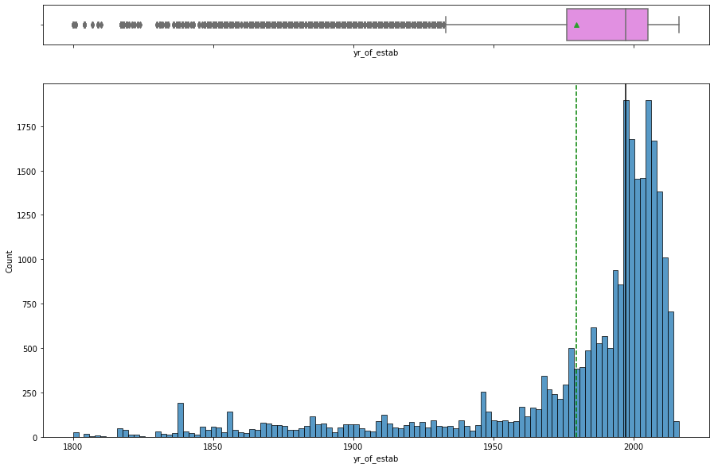

```python
histogram_boxplot(data,'yr_of_estab')
```

-There is a left skewed distribution present in the variable.

-The distribution is not symmetric.

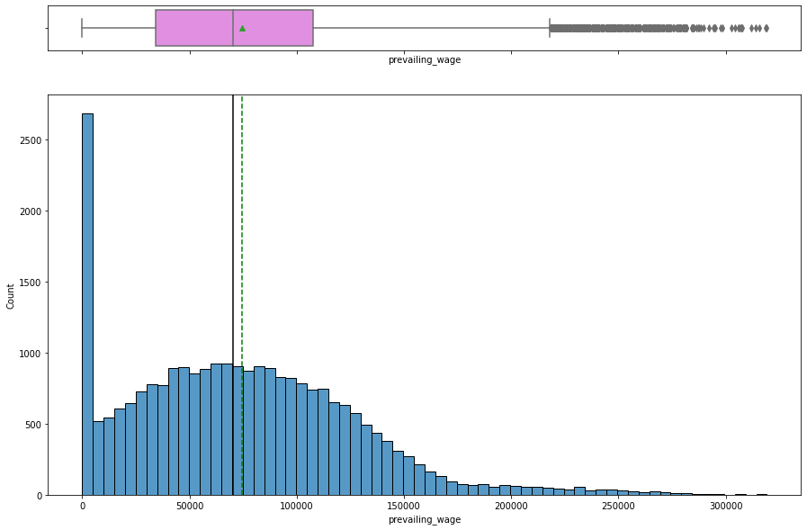

```python
histogram_boxplot(data,'prevailing_wage')
```

-There are many outliers in the prevailing wage the company gives, this can be explained because most companies pay wages within the average market wage, and there are very few companies that pay above the average.

-There is a right skewed distribution present in the variable.

-The distribution is not symmetric.

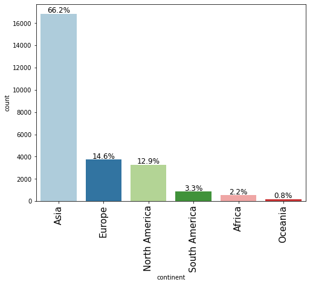

```python
labeled_barplot(data,'continent',perc=True)
```

Most job applicants come from Asia, followed by Europe and North America.

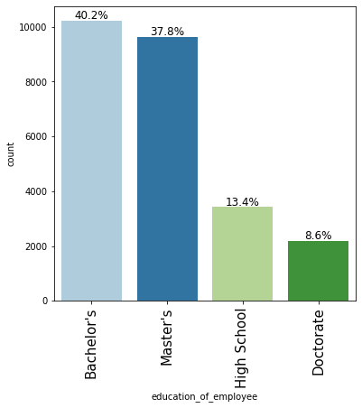

```python
labeled_barplot(data,'education_of_employee',perc=True)
```

Most applicants have either a Bachelor's or a Master's degree.

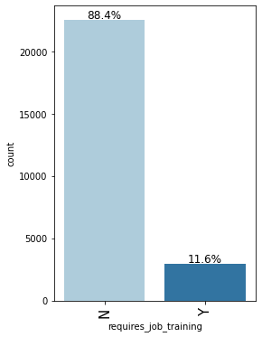

```python
labeled_barplot(data,'requires_job_training',perc=True)
```

Most job applicants do not require job training.

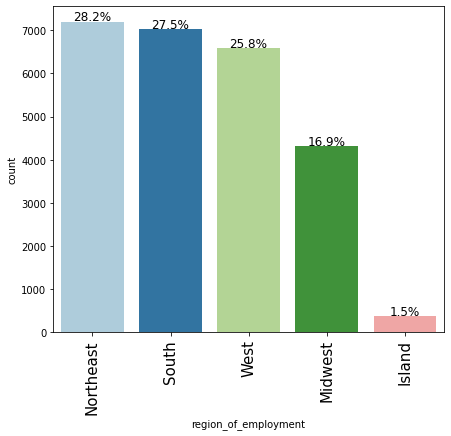

```python
labeled_barplot(data,'region_of_employment',perc=True)
```

Most applicants are applying in the northeast, south and west parts of the USA.

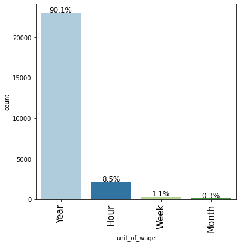

```python
labeled_barplot(data,'unit_of_wage',perc=True)
```

Most wages are calculated on a yearly basis.

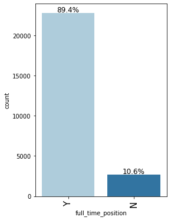

```python
labeled_barplot(data,'full_time_position',perc=True)
```

Most applicants are applying for a full time position

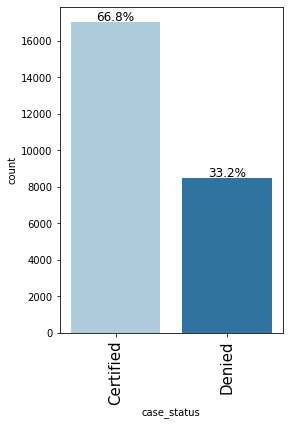

```python
labeled_barplot(data,'case_status',perc=True)
```

Most applicants have a certified visa, although a third part of the applicants have been denied their visas.

## **Bivariate analysis**

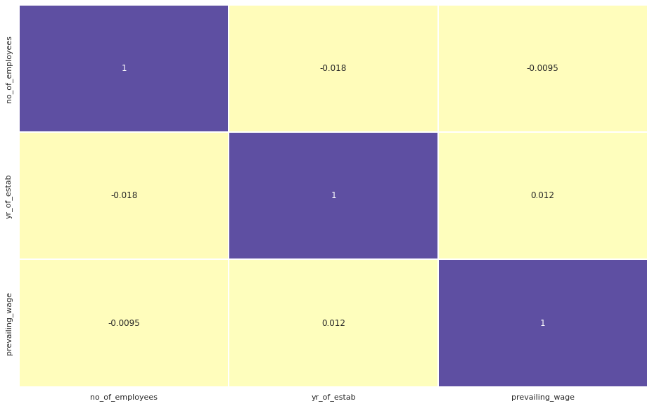

```python
sns.set(rc={'figure.figsize':(16,10)})
sns.heatmap(data.corr(),
            annot=True,
            linewidths=.5,
            center=0,
            cbar=False,
            cmap="Spectral")
plt.show()
```

There are no strong correlations among the numerical variables.

```
case_status    Certified  Denied    All
continent
All                17018    8462  25480
Asia               11012    5849  16861
North America       2037    1255   3292
Europe              2957     775   3732
South America        493     359    852
Africa               397     154    551
Oceania              122      70    192
------------------------------------------------------------------------------------------------------------------------
```

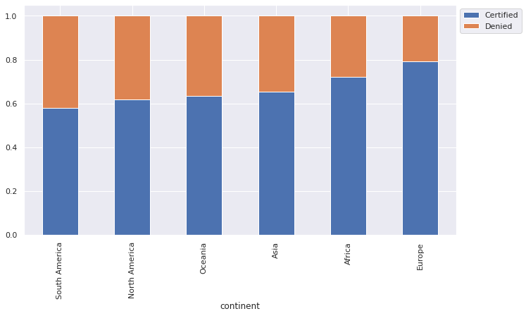

```python
stacked_barplot(data, "continent", "case_status")
```

South America is the continent with the most denied visas while Europe is the continent with the most accepted visas.

```
case_status            Certified  Denied    All
education_of_employee
All                        17018    8462  25480
Bachelor's                  6367    3867  10234
High School                 1164    2256   3420
Master's                    7575    2059   9634
Doctorate                   1912     280   2192
------------------------------------------------------------------------------------------------------------------------
```

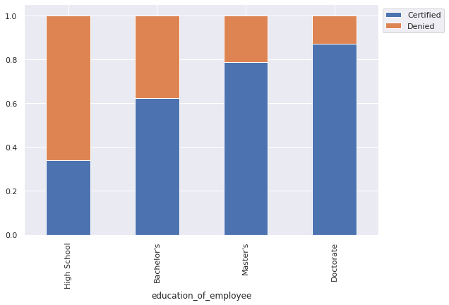

```python
stacked_barplot(data, "education_of_employee", "case_status")
```

The higher the education, the more likely an employee is to have a certified visa.

```
case_status            Certified  Denied    All
requires_job_training
All                        17018    8462  25480
N                          15012    7513  22525
Y                           2006     949   2955
------------------------------------------------------------------------------------------------------------------------
```

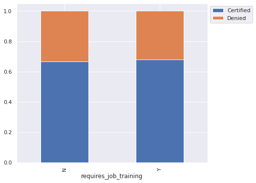

```python
stacked_barplot(data, "requires_job_training", "case_status")
```

```
case_status   Certified  Denied    All
unit_of_wage
All               17018    8462  25480
Year              16047    6915  22962
Hour                747    1410   2157
Week                169     103    272
Month                55      34     89
------------------------------------------------------------------------------------------------------------------------
```

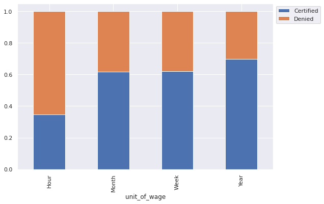

```python
stacked_barplot(data, "unit_of_wage", "case_status")
```

The workers with the most likelihood to get a Visa are the ones with a yearly wage.

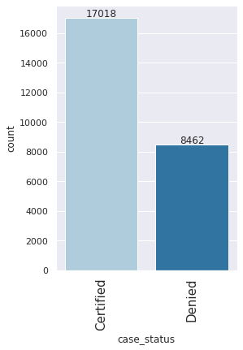

```python
labeled_barplot(data,"case_status",'prevailing_wage')
```

*Leading Questions:*

**1.- Those with higher education may want to travel abroad for a well-paid job. Does education play a role in Visa certification?**

**2.-How does the visa status vary across different continents?**

**4.-In the United States, employees are paid at different intervals. Which pay unit is most likely to be certified for a visa?**

The employees with a yearly wage are the most likely to get a certified Visa.

## **Data preprocessing**

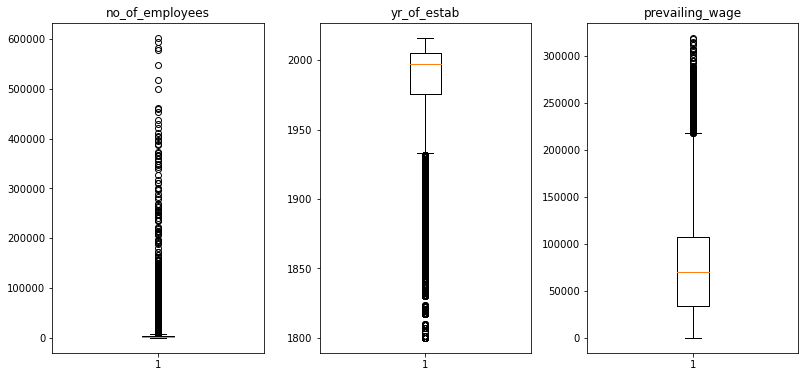

```python
# outlier detection using boxplot
numeric_columns = data.select_dtypes(include=np.number).columns.tolist()


plt.figure(figsize=(15, 20))

for i, variable in enumerate(numeric_columns):
    plt.subplot(4, 4, i + 1)
    plt.boxplot(data[variable], whis=1.5)
    plt.tight_layout()
    plt.title(variable)

plt.show()
```

There is a huge number of outliers in the three numerical variables.

#### **Actions for data preprocessing**

```python
df6 = pd.get_dummies(data,columns =["case_status"])
df5 = pd.get_dummies(df6,columns=["continent"])
df4 = pd.get_dummies(df5,columns=["education_of_employee"])
df3 = pd.get_dummies(df4,columns=["requires_job_training"])
df2 = pd.get_dummies(df3,columns=["region_of_employment"])
df1 = pd.get_dummies(df2,columns=["unit_of_wage"])
df = pd.get_dummies(df1,columns=["full_time_position"])
df.head()
```

|  | no_of_employees | yr_of_estab | prevailing_wage | case_status_Certified | case_status_Denied | continent_Africa | continent_Asia | continent_Europe | continent_North America | continent_Oceania | ... | region_of_employment_Midwest | region_of_employment_Northeast | region_of_employment_South | region_of_employment_West | unit_of_wage_Hour | unit_of_wage_Month | unit_of_wage_Week | unit_of_wage_Year | full_time_position_N | full_time_position_Y |
| --- | --- | --- | --- | --- | --- | --- | --- | --- | --- | --- | --- | --- | --- | --- | --- | --- | --- | --- | --- | --- | --- |
| 0 | 14513 | 2007 | 592.2029 | 0 | 1 | 0 | 1 | 0 | 0 | 0 | ... | 0 | 0 | 0 | 1 | 1 | 0 | 0 | 0 | 0 | 1 |
| 1 | 2412 | 2002 | 83425.6500 | 1 | 0 | 0 | 1 | 0 | 0 | 0 | ... | 0 | 1 | 0 | 0 | 0 | 0 | 0 | 1 | 0 | 1 |
| 2 | 44444 | 2008 | 122996.8600 | 0 | 1 | 0 | 1 | 0 | 0 | 0 | ... | 0 | 0 | 0 | 1 | 0 | 0 | 0 | 1 | 0 | 1 |
| 3 | 98 | 1897 | 83434.0300 | 0 | 1 | 0 | 1 | 0 | 0 | 0 | ... | 0 | 0 | 0 | 1 | 0 | 0 | 0 | 1 | 0 | 1 |
| 4 | 1082 | 2005 | 149907.3900 | 1 | 0 | 1 | 0 | 0 | 0 | 0 | ... | 0 | 0 | 1 | 0 | 0 | 0 | 0 | 1 | 0 | 1 |

5 rows × 28 columns

```python
df["prevailing_wage"].median()
```

```
70308.20999999999
```

```python
df["no_of_employees"].median()
```

```
2109.0
```

```python
df["yr_of_estab"].median()
```

```
1997.0
```

```python
median = df.loc[df['prevailing_wage']<70308.20999999999, 'prevailing_wage'].median()
df.loc[df.prevailing_wage > 70308.20999999999, 'prevailing_wage'] = np.nan
df.fillna(median,inplace=True)
```

```python
median = df.loc[df['no_of_employees']<2109.0, 'no_of_employees'].median()
df.loc[df.no_of_employees > 2109.0, 'no_of_employees'] = np.nan
df.fillna(median,inplace=True)
```

```python
median = df.loc[df['yr_of_estab']<1997.0, 'yr_of_estab'].median()
df.loc[df.yr_of_estab > 1997.0, 'yr_of_estab'] = np.nan
df.fillna(median,inplace=True)
```

```python
df.info()
```

```
<class 'pandas.core.frame.DataFrame'>
RangeIndex: 25480 entries, 0 to 25479
Data columns (total 28 columns):
 #   Column                             Non-Null Count  Dtype
---  ------                             --------------  -----
 0   no_of_employees                    25480 non-null  float64
 1   yr_of_estab                        25480 non-null  float64
 2   prevailing_wage                    25480 non-null  float64
 3   case_status_Certified              25480 non-null  uint8
 4   case_status_Denied                 25480 non-null  uint8
 5   continent_Africa                   25480 non-null  uint8
 6   continent_Asia                     25480 non-null  uint8
 7   continent_Europe                   25480 non-null  uint8
 8   continent_North America            25480 non-null  uint8
 9   continent_Oceania                  25480 non-null  uint8
```

[output cut: 20 more lines]

```python
#Drop the repeated values in binary dummies
df.drop(columns=['full_time_position_N'], inplace=True)
df.drop(columns=['requires_job_training_N'], inplace=True)
df.drop(columns=['case_status_Denied'], inplace=True)
```

```python
#Separating features from the target column

X = df.drop('case_status_Certified', axis=1)
y = df['case_status_Certified']
```

```python
# Splitting the data into train and test sets in 80:20 ratio
X_train, X_test, y_train, y_test = train_test_split(X, y, test_size=0.20, random_state=1, shuffle=True)
```

```python
X_train.shape, X_test.shape
```

```
((20384, 24), (5096, 24))
```

### We have 20384 observations on the train set and 5096 observations on the test set.

## **Model building and hyperparameter tuning.**

We'll fit different models on the train data and observe their performance.

Our goal is to improve that performance by tuning some hyperparameters.

We'll use GridSearchCv for hyperparameter tuning and r_2 score to optimize the model.

R-square - Coefficient of determination is used to evaluate the performance of a regression model. It is the amount of the variation in the output dependent attribute which is predictable from the input independent variables.

Let's start by creating a function to get model scores, so that we don't have to use the same codes repeatedly.

```python
# function to compute adjusted R-squared
def adj_r2_score(predictors, targets, predictions):
    r2 = r2_score(targets, predictions)
    n = predictors.shape[0]
    k = predictors.shape[1]
    return 1 - ((1 - r2) * (n - 1) / (n - k - 1))


# function to compute MAPE
def mape_score(targets, predictions):
    return np.mean(np.abs(targets - predictions) / targets) * 100


# function to compute different metrics to check performance of a regression model
def model_performance_regression(model, predictors, target):
    """
    Function to compute different metrics to check regression model performance

    model: regressor
    predictors: independent variables
    target: dependent variable
    """

    # predicting using the independent variables
    pred = model.predict(predictors)

    r2 = r2_score(target, pred)  # Computing R-squared
    adjr2 = adj_r2_score(predictors, target, pred)  # Computing adjusted R-squared
    rmse = np.sqrt(mean_squared_error(target, pred))  #  RMSE
    mae = mean_absolute_error(target, pred)  # MAE
    mape = mape_score(target, pred)  # MAPE

    # creating a dataframe of metrics
    df_perf = pd.DataFrame(
        {
            "RMSE": rmse,
            "MAE": mae,
            "R-squared": r2,
            "Adj. R-squared": adjr2,
            "MAPE": mape,
        },
        index=[0],
    )

    return df_perf
```

```python
##  Function to calculate r2_score and RMSE on train and test data
def get_model_score(model, flag=True):
    '''
    model : classifier to predict values of X

    '''
    # defining an empty list to store train and test results
    score_list=[]

    pred_train = model.predict(X_train)
    pred_test = model.predict(X_test)

    train_r2=metrics.r2_score(y_train,pred_train)
    test_r2=metrics.r2_score(y_test,pred_test)
    train_rmse=np.sqrt(metrics.mean_squared_error(y_train,pred_train))
    test_rmse=np.sqrt(metrics.mean_squared_error(y_test,pred_test))

    #Adding all scores in the list
    score_list.extend((train_r2,test_r2,train_rmse,test_rmse))

    # If the flag is set to True then only the following print statements will be dispayed, the default value is True
    if flag==True:
        print("R-sqaure on training set : ",metrics.r2_score(y_train,pred_train))
        print("R-square on test set : ",metrics.r2_score(y_test,pred_test))
        print("RMSE on training set : ",np.sqrt(metrics.mean_squared_error(y_train,pred_train)))
        print("RMSE on test set : ",np.sqrt(metrics.mean_squared_error(y_test,pred_test)))

    # returning the list with train and test scores
    return score_list
```

```python
from sklearn import preprocessing
```

```python
dtree=DecisionTreeRegressor(random_state=1)
dtree.fit(X_train,y_train)
```

```
DecisionTreeRegressor(random_state=1)
```

```python
from sklearn.metrics import r2_score, mean_squared_error, mean_absolute_error
```

```python
dtree_model_train_perf=model_performance_regression(dtree, X_train,y_train)
print("Training performance \n",dtree_model_train_perf)
```

```
Training performance
        RMSE       MAE  R-squared  Adj. R-squared  MAPE
0  0.164402  0.054056   0.878688        0.878545   inf
```

```python
dtree_model_test_perf=model_performance_regression(dtree, X_test,y_test)
print("Testing performance \n",dtree_model_test_perf)
```

```
Testing performance
        RMSE       MAE  R-squared  Adj. R-squared  MAPE
0  0.580474  0.363226  -0.547843       -0.555169   inf
```

-Overfitting is present in our current model.

-We will try to reduce the overfitting noise by tuning our hyperparameters.

## **Hyperparameter tuning**

```python
# Choose the type of classifier.
dtree_tuned = DecisionTreeRegressor(random_state=1)

# Grid of parameters to choose from
parameters = {'max_depth': list(np.arange(2,30)) + [None],
              'min_samples_leaf': [1, 3, 5, 7, 10],
              'max_leaf_nodes' : [2, 3, 5, 10, 15] + [None],
              'min_impurity_decrease': [0.001, 0.01, 0.1, 0.0]
             }

# Type of scoring used to compare parameter combinations
scorer = metrics.make_scorer(metrics.r2_score)

# Run the grid search
grid_obj = GridSearchCV(dtree_tuned, parameters, scoring=scorer,cv=5)
grid_obj = grid_obj.fit(X_train, y_train)

# Set the clf to the best combination of parameters
dtree_tuned = grid_obj.best_estimator_

# Fit the best algorithm to the data.
dtree_tuned.fit(X_train, y_train)
```

```
DecisionTreeRegressor(max_depth=7, max_leaf_nodes=15, random_state=1)
```

```python
dtree_tuned_model_train_perf = model_performance_regression(dtree_tuned, X_train,y_train)
print("Training performance \n",dtree_model_train_perf)
```

```
Training performance
        RMSE       MAE  R-squared  Adj. R-squared  MAPE
0  0.164402  0.054056   0.878688        0.878545   inf
```

```python
dtree_tuned_model_test_perf = model_performance_regression(dtree_tuned, X_test,y_test)
print("Testing performance \n",dtree_tuned_model_test_perf)
```

```
Testing performance
        RMSE       MAE  R-squared  Adj. R-squared  MAPE
0  0.427565  0.365154    0.16022        0.156246   inf
```

# Plotting the feature importance of each variable

```python
#Gini importance
print(pd.DataFrame(dtree_tuned.feature_importances_, columns = ["Imp"], index = X_train.columns).sort_values(by = 'Imp', ascending = False))
```

```
                                        Imp
education_of_employee_High School  0.429629
unit_of_wage_Hour                  0.246982
education_of_employee_Bachelor's   0.157635
continent_Europe                   0.058905
region_of_employment_West          0.022154
continent_North America            0.017585
region_of_employment_Midwest       0.015878
region_of_employment_South         0.015558
full_time_position_Y               0.011971
region_of_employment_Northeast     0.008906
continent_South America            0.007939
prevailing_wage                    0.006858
unit_of_wage_Year                  0.000000
unit_of_wage_Week                  0.000000
unit_of_wage_Month                 0.000000
no_of_employees                    0.000000
region_of_employment_Island        0.000000
requires_job_training_Y            0.000000
yr_of_estab                        0.000000
education_of_employee_Doctorate    0.000000
continent_Oceania                  0.000000
continent_Asia                     0.000000
continent_Africa                   0.000000
education_of_employee_Master's     0.000000
```

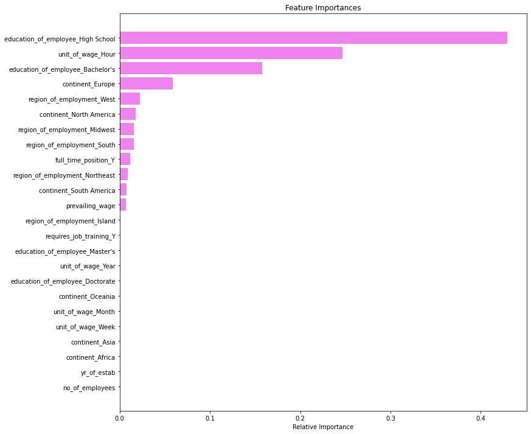

```python
feature_names = X_train.columns
importances = dtree_tuned.feature_importances_
indices = np.argsort(importances)

plt.figure(figsize=(12,12))
plt.title('Feature Importances')
plt.barh(range(len(indices)), importances[indices], color='violet', align='center')
plt.yticks(range(len(indices)), [feature_names[i] for i in indices])
plt.xlabel('Relative Importance')
plt.show()
```

-High School education seems to be the most important variable considering relative importance, followed by hourly unit wage and Bachelor's degree.

# Random Forrest model

```python
rf_estimator=RandomForestRegressor(random_state=1)
rf_estimator.fit(X_train,y_train)
```

```
RandomForestRegressor(random_state=1)
```

```python
rf_estimator_model_train_perf = model_performance_regression(rf_estimator, X_train,y_train)
print("Training performance \n",rf_estimator_model_train_perf)
```

```
Training performance
        RMSE       MAE  R-squared  Adj. R-squared  MAPE
0  0.226791  0.165634   0.769143        0.768871   inf
```

```python
rf_estimator_model_test_perf = model_performance_regression(rf_estimator, X_test,y_test)
print("Testing performance \n",rf_estimator_model_test_perf)
```

```
Testing performance
        RMSE       MAE  R-squared  Adj. R-squared  MAPE
0  0.460829  0.364327   0.024472        0.019855   inf
```

# Hyperparameter tuning

```python
# Choose the type of classifier.
rf_tuned = RandomForestRegressor(random_state=1)

# Grid of parameters to choose from
parameters = {
                'max_depth':[4, 6, 8, 10, None],
                'max_features': ['sqrt','log2',None],
                'n_estimators': [80, 90, 100, 110, 120]
}

# Type of scoring used to compare parameter combinations
scorer = metrics.make_scorer(metrics.r2_score)

# Run the grid search
grid_obj = GridSearchCV(rf_tuned, parameters, scoring=scorer,cv=5)
grid_obj = grid_obj.fit(X_train, y_train)

# Set the clf to the best combination of parameters
rf_tuned = grid_obj.best_estimator_

# Fit the best algorithm to the data.
rf_tuned.fit(X_train, y_train)
```

```
RandomForestRegressor(max_depth=10, max_features='sqrt', n_estimators=110,
                      random_state=1)
```

```python
rf_tuned_model_train_perf = model_performance_regression(rf_tuned, X_train, y_train)
print("Training performance \n",rf_tuned_model_train_perf)
```

```
Training performance
        RMSE       MAE  R-squared  Adj. R-squared  MAPE
0  0.410626  0.355137   0.243197        0.242305   inf
```

```python
rf_tuned_model_test_perf = model_performance_regression(rf_tuned, X_test, y_test)
print("Testing performance \n",rf_tuned_model_test_perf)
```

```
Testing performance
        RMSE       MAE  R-squared  Adj. R-squared  MAPE
0  0.426759  0.368448   0.163384        0.159424   inf
```

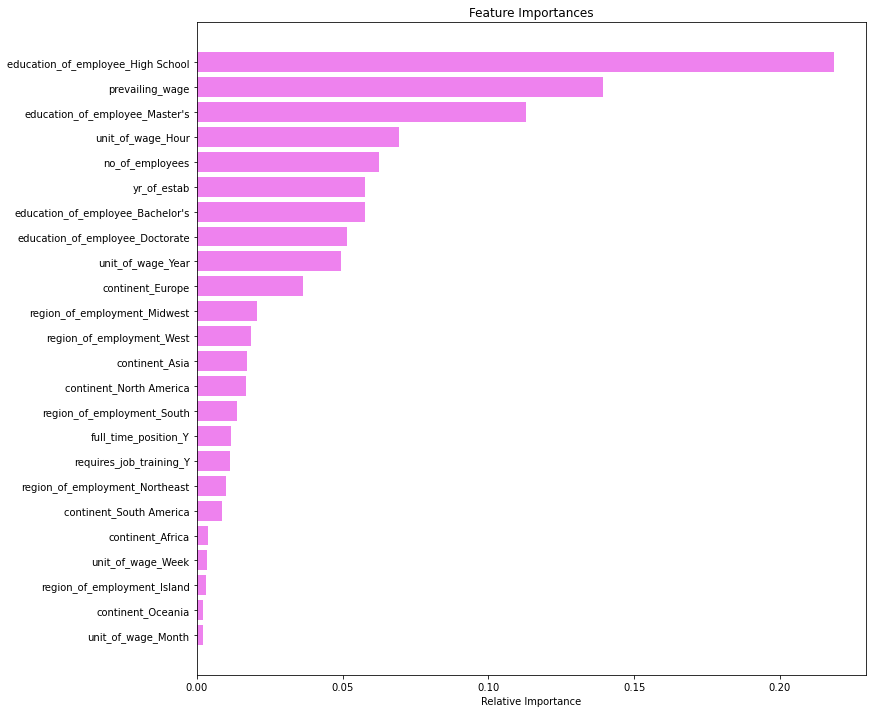

```python
feature_names = X_train.columns
importances = rf_tuned.feature_importances_
indices = np.argsort(importances)

plt.figure(figsize=(12,12))
plt.title('Feature Importances')
plt.barh(range(len(indices)), importances[indices], color='violet', align='center')
plt.yticks(range(len(indices)), [feature_names[i] for i in indices])
plt.xlabel('Relative Importance')
plt.show()
```

# Boosting

```python
ab_regressor=AdaBoostRegressor(random_state=1)
ab_regressor.fit(X_train,y_train)
```

```
AdaBoostRegressor(random_state=1)
```

```python
ab_regressor_model_train_perf = model_performance_regression(ab_regressor, X_train,y_train)
print("Training performance \n",ab_regressor_model_train_perf)
```

```
Training performance
        RMSE       MAE  R-squared  Adj. R-squared  MAPE
0  0.435255  0.391245   0.149687        0.148684   inf
```

```python
ab_regressor_model_test_perf = model_performance_regression(ab_regressor, X_test,y_test)
print("Testing performance \n",ab_regressor_model_test_perf)
```

```
Testing performance
        RMSE       MAE  R-squared  Adj. R-squared  MAPE
0  0.435908  0.391473   0.127127        0.122996   inf
```

The test is running well, but is performing very poorly nontheless.

# Hyperparameter tuning

```python
# Choose the type of classifier.
ab_tuned = AdaBoostRegressor(random_state=1)

# Grid of parameters to choose from
parameters = {'n_estimators': np.arange(10,100,10),
              'learning_rate': [1, 0.1, 0.5, 0.01],
              }

# Type of scoring used to compare parameter combinations
scorer = metrics.make_scorer(metrics.r2_score)

# Run the grid search
grid_obj = GridSearchCV(ab_tuned, parameters, scoring=scorer,cv=5)
grid_obj = grid_obj.fit(X_train, y_train)

# Set the clf to the best combination of parameters
ab_tuned = grid_obj.best_estimator_

# Fit the best algorithm to the data.
ab_tuned.fit(X_train, y_train)
```

```
AdaBoostRegressor(learning_rate=0.01, n_estimators=70, random_state=1)
```

```python
ab_tuned_model_train_perf = model_performance_regression(ab_tuned, X_train,y_train)
print("Training performance \n",ab_tuned_model_train_perf)
```

```
Training performance
        RMSE       MAE  R-squared  Adj. R-squared  MAPE
0  0.434229  0.379609   0.153691        0.152693   inf
```

```python
ab_tuned_model_test_perf = model_performance_regression(ab_tuned, X_test,y_test)
print("Testing performance \n",ab_tuned_model_test_perf)
```

```
Testing performance
        RMSE       MAE  R-squared  Adj. R-squared  MAPE
0  0.434921  0.379715   0.131077        0.126965   inf
```

There is no significant change by tuning the hyperparameters.

# Actionable Insights and Recommendations